# Homework 2

Nathan Hernandez

Sunday, September 21, 2014

# Part 1

**Problem 1**  
The set of data containing the elements {3, 5, 8, 15, 20, 21} produces a mean of 12 and a median of 11.5

```r
data <- c(3,5,8,15,20,21)
mean(data)
```

```
## [1] 12
```

```r
median(data)
```

```
## [1] 11.5
```

If we apply the logarthim to our set of data an calculate the mean and median, we get 2.255966 and 2.393746 respectively.

```r
logData <-log(data)
mean(logData)
```

```
## [1] 2.256
```

```r
median(logData)
```

```
## [1] 2.394
```

Thus, we can conclude that neither mean nor median of our set of data is equivalent to the mean or median of our set of data after a logarithm function has been applied to the elements within the set of data.

**Problem 2**

This problem is functionally similar to problem 1, except that the data set and function applied to the data set are different.

```r
data <- c(2,2,4,5,6,8,11,15)
mean(data)
```

```
## [1] 6.625
```

```r
median(data)
```

```
## [1] 5.5
```

```r
sqrtData <-sqrt(data)
mean(sqrtData)
```

```
## [1] 2.442
```

```r
median(sqrtData)
```

```
## [1] 2.343
```

**Problem 3**

1. Only in the case where the real-valued function does not change the value of its input.
2. Only in the case where the real-valued function does not change the value of its input.
3. Yes, in the case where the real-valued function does not change the value of its input.
4. Yes, in the case where the real-valued function does not change the value of its input.

**Problem 4**  
a.

```r
FlightDelays <- read.csv(file = url("http://www1.appstate.edu/~thomleyje/data-files/FlightDelays.csv"))
DepartTime <- FlightDelays$DepartTime

table(DepartTime)
```

```
## DepartTime
##    4-8am    4-8pm    8-Mid   8-Noon Noon-4pm
##      699      972      257     1053     1048
```

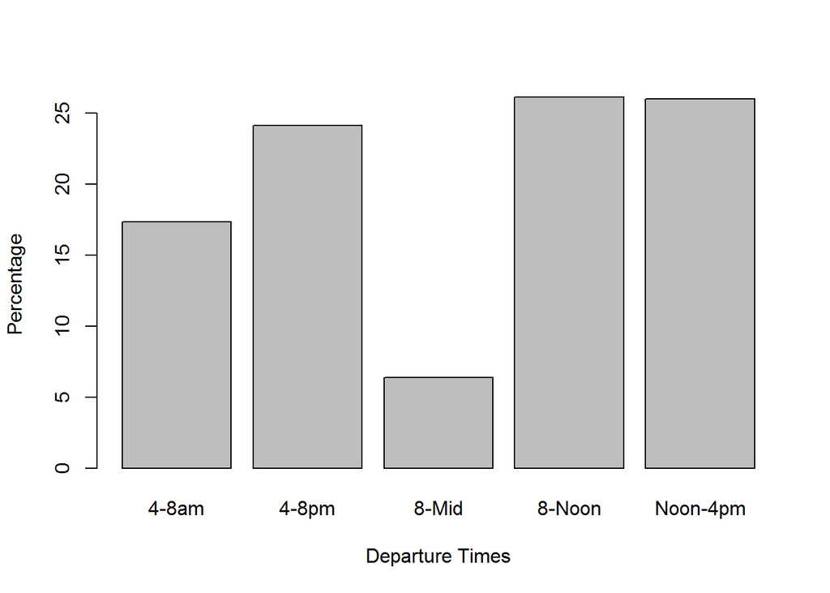

b.

```r
prop.table(table(FlightDelays$Delayed30,FlightDelays$Day))*100
```

```
##
##          Fri    Mon    Sat    Sun    Thu    Tue    Wed
##   No  12.236 14.123 10.077 12.584 10.772 13.279 12.112
##   Yes  3.574  1.514  1.167  1.092  3.276  2.308  1.886
```

The percentage of flight delayed less than 30 minutes is:

```
## [1] 85.18
```

The percentage of flight delayed at least 30 minutes is:

```
## [1] 14.82
```

c.

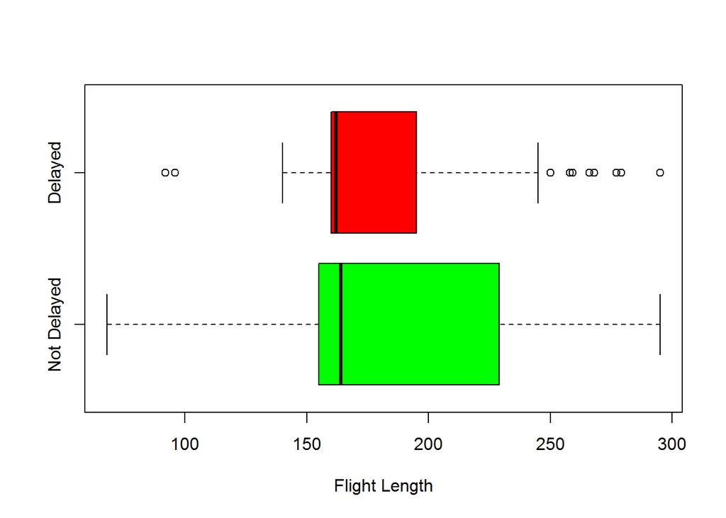

```r
notDelayed <- subset(FlightDelays, Delayed30=='No')
delayed <- subset(FlightDelays, Delayed30=='Yes')
boxplot(notDelayed$FlightLength, delayed$FlightLength,
        names=c("Not Delayed", "Delayed"),
        col=c("green","red"),
        xlab="Flight Length",
        horizontal=TRUE)
```

**Problem 5**

a.

```r
Survey <- read.csv(file = url("http://www1.appstate.edu/~thomleyje/data-files/GSS2002.csv"))
DeathPenalty <- Survey$DeathPenalty
table(DeathPenalty)
```

```
## DeathPenalty
##  Favor Oppose
##    899    409
```

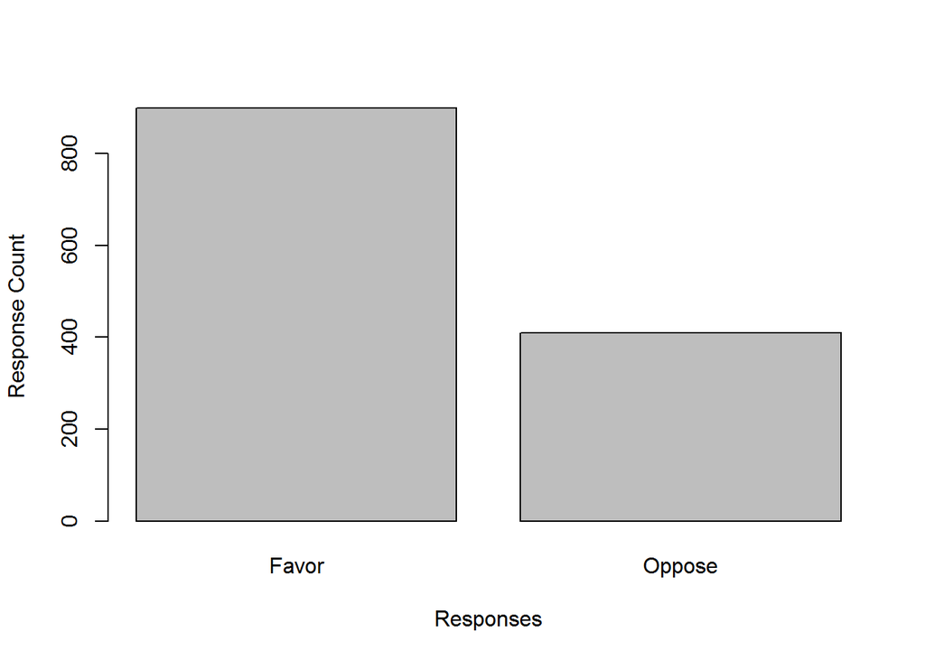

2. The summary command tells us how many people answered “NA,” the table command does not.

```r
GunOwnership <- Survey$OwnGun
table(GunOwnership)
```

```
## GunOwnership
##      No Refused     Yes
##     605       9     310
```

```r
summary(GunOwnership)
```

```
##      No Refused     Yes    NA's
##     605       9     310    1841
```

c.

```r
prop.table(table(GunOwnership,DeathPenalty),1)*100
```

```
##             DeathPenalty
## GunOwnership Favor Oppose
##      No      65.33  34.67
##      Refused 77.78  22.22
##      Yes     80.46  19.54
```

4. 80.46% of people who claimed they own a gun favor the death penalty. 65.33% of people who claimed they did not own a gun favored the death penalty. There does appear to be a difference of proportions in this regard.

# Part 2

**Problem 1**

```r
Berkeley <- read.csv(file = url("http://www1.appstate.edu/~thomleyje/data-files/Berkeley.csv"))
```

**Problem 2**

```r
Sex <- Berkeley$Sex
table(Sex)
```

```
## Sex
## Female   Male
##   1835   2691
```

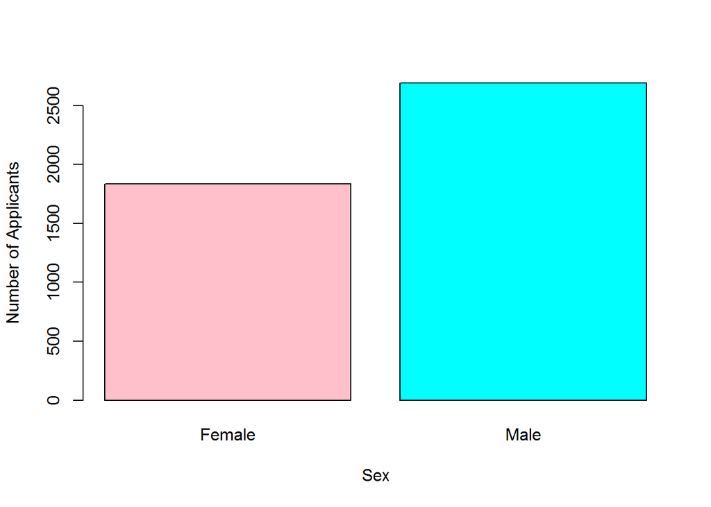

**Problem 3**

```r
Department <- Berkeley$Department
table(Department)
```

```
## Department
##   A   B   C   D   E   F
## 933 585 918 792 584 714
```

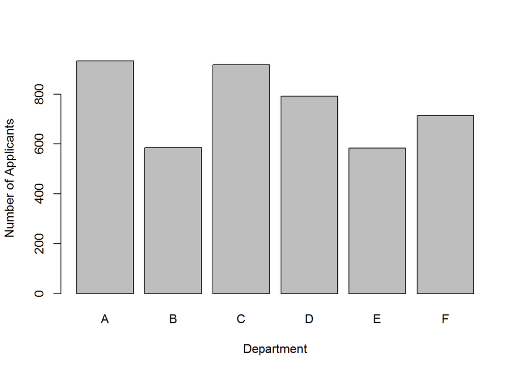

**Problem 4**

```r
table(Sex,Department)
```

```
##         Department
## Sex        A   B   C   D   E   F
##   Female 108  25 593 375 393 341
##   Male   825 560 325 417 191 373
```

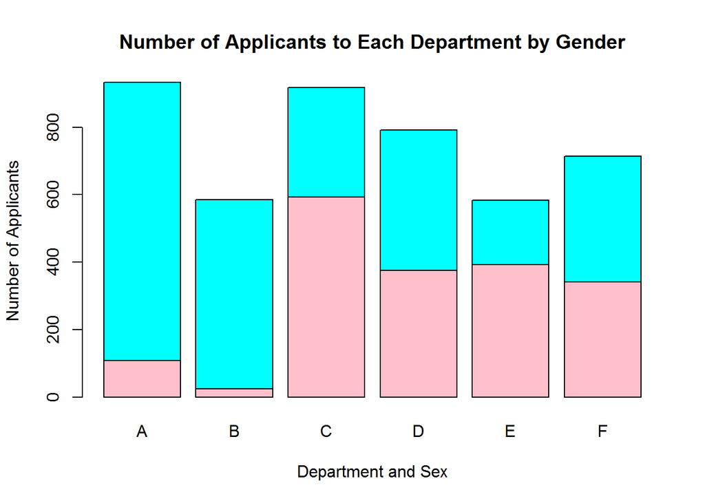

**Problem 5**

```r
Status <- Berkeley$Status
round(prop.table(table(Status,Sex),2)*100,1)
```

```
##           Sex
## Status     Female Male
##   Accepted   30.4 44.5
##   Rejected   69.6 55.5
```

**Problem 6**

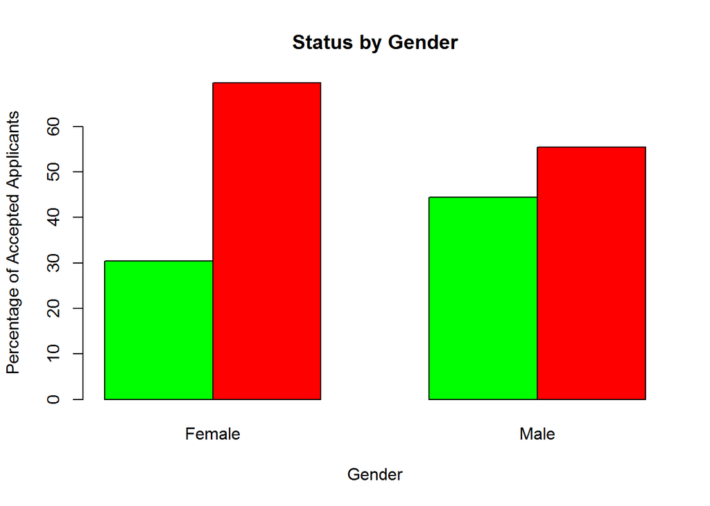

**Problem 7**

```r
DeptA <- subset(Berkeley, Department=='A')
DeptB <- subset(Berkeley, Department=='B')
DeptC <- subset(Berkeley, Department=='C')
DeptD <- subset(Berkeley, Department=='D')
DeptE <- subset(Berkeley, Department=='E')
DeptF <- subset(Berkeley, Department=='F')
```

**Problem 8**

a.

```r
round(prop.table(table(DeptA$Status,DeptA$Sex),2)*100,1)
```

```
##
##            Female Male
##   Accepted   82.4 62.1
##   Rejected   17.6 37.9
```

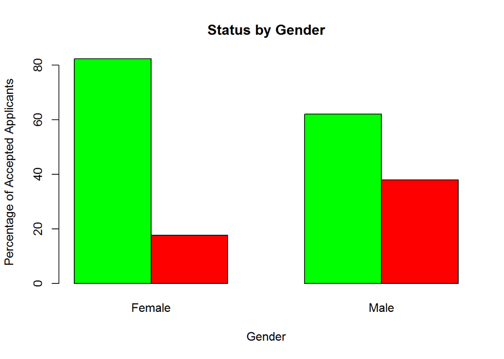

b.

```r
round(prop.table(table(DeptB$Status,DeptB$Sex),2)*100,1)
```

```
##
##            Female Male
##   Accepted     68   63
##   Rejected     32   37
```

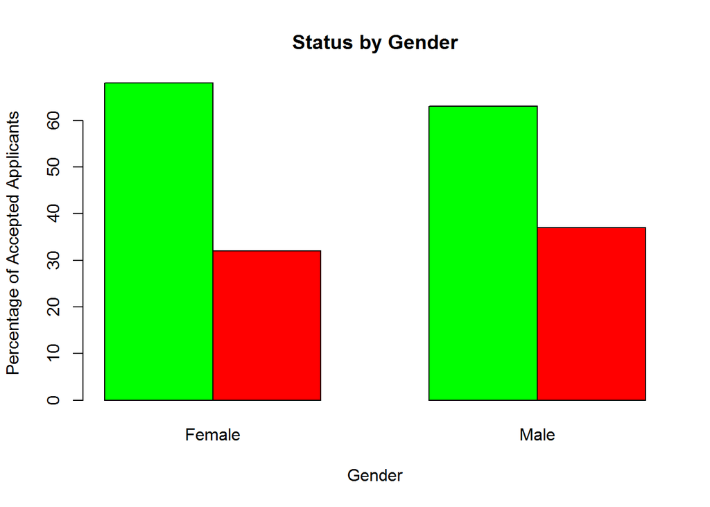

c.

```r
round(prop.table(table(DeptC$Status,DeptC$Sex),2)*100,1)
```

```
##
##            Female Male
##   Accepted   34.1 36.9
##   Rejected   65.9 63.1
```

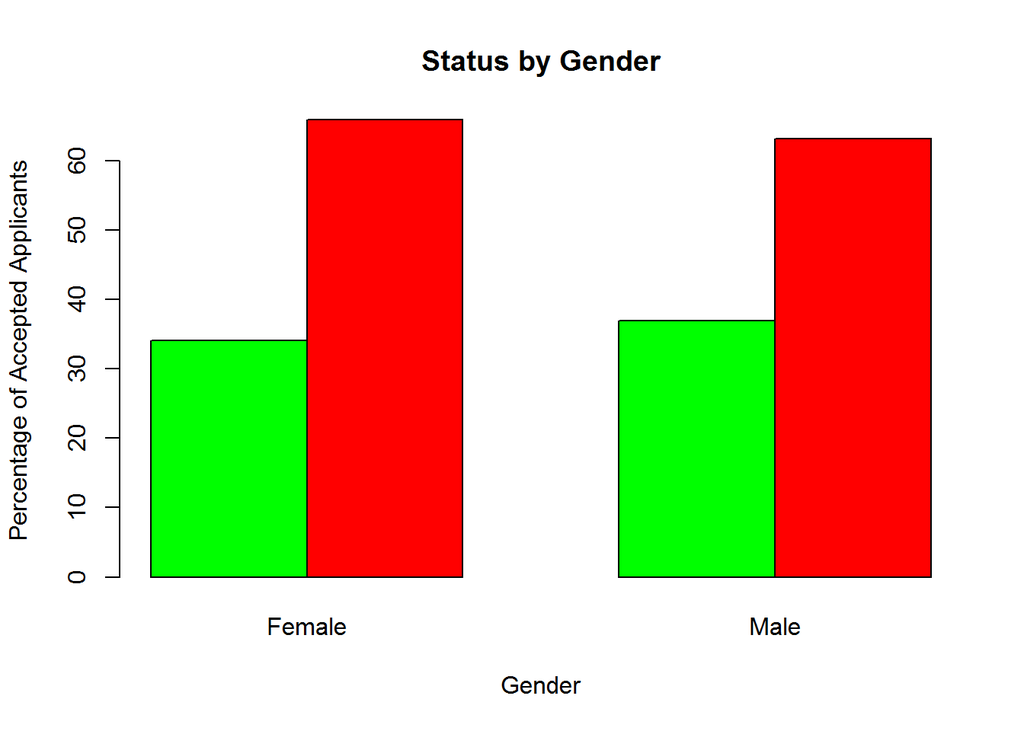

d.

```r
round(prop.table(table(DeptD$Status,DeptD$Sex),2)*100,1)
```

```
##
##            Female Male
##   Accepted   34.9 33.1
##   Rejected   65.1 66.9
```

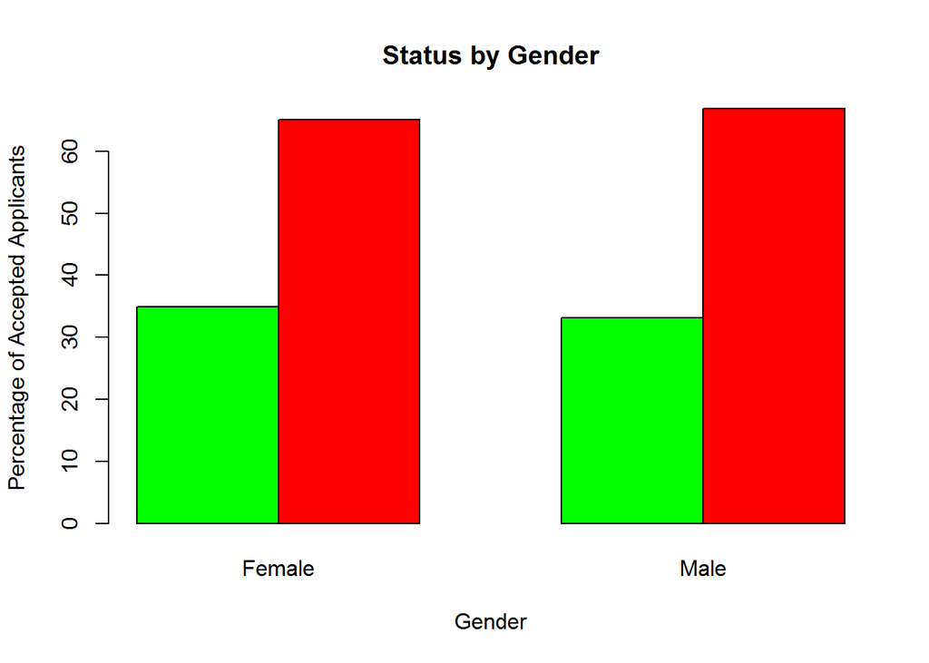

e.

```r
round(prop.table(table(DeptE$Status,DeptE$Sex),2)*100,1)
```

```
##
##            Female Male
##   Accepted   23.9 27.7
##   Rejected   76.1 72.3
```

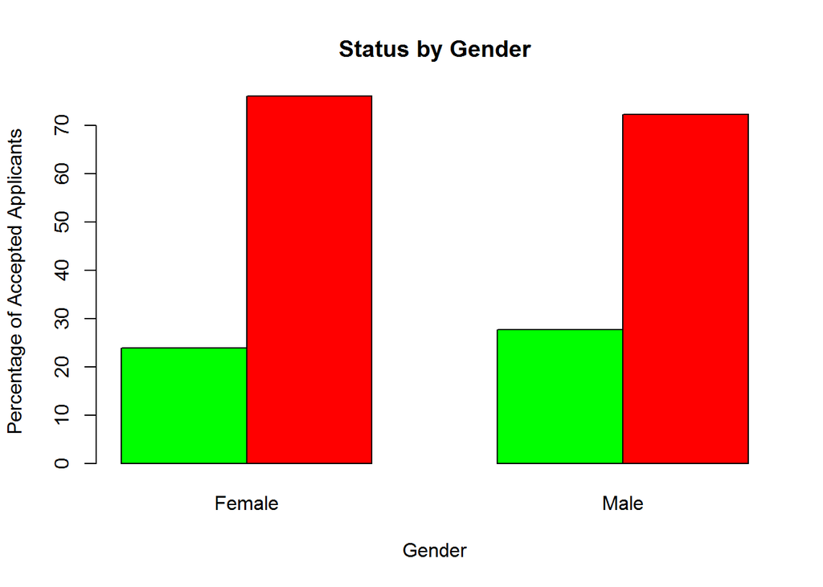

f.

```r
round(prop.table(table(DeptF$Status,DeptF$Sex),2)*100,1)
```

```
##
##            Female Male
##   Accepted    7.0  5.9
##   Rejected   93.0 94.1
```

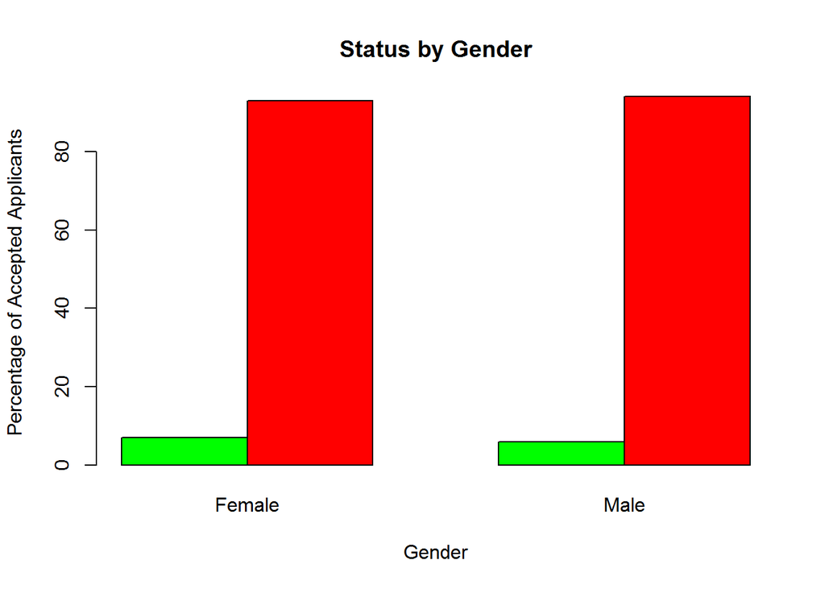